# bike-share_analysis_v1

Zuhair

2023-04-02

## Business task

I have been assigned to determine how annual members and nonmember riders use the company’s bikes differently and why nonmember riders might purchase the membership.

Data is provided from https://www.kaggle.com/datasets/jorge4141/case-study-cyclistic-bikeshare-analysis.

## Libraries and setup

```r
library(tidyverse)
data_path <- list.files(path = "./bike_share_data", pattern = "*.csv", full.names = TRUE)
```

## Finding the sample size

Because we have a large amount of data to process, we can run analysis on a sample instead. The first step will be to create a function that adds all records from the csv files and gives us the total.

We should also take a look at what our columns are.

```r
total_adder <- function(list_of_csvs) {
  total_records = 0

  for (csv in list_of_csvs) {
    df <- read_csv(csv, show_col_types = FALSE)
    total_records <- total_records + nrow(df)
  }
  print(paste("total records:", total_records))
  colnames(df)
}
total_adder(data_path)
```

```
## [1] "total records: 5755694"
```

```
##  [1] "ride_id"            "rideable_type"      "started_at"
##  [4] "ended_at"           "start_station_name" "start_station_id"
##  [7] "end_station_name"   "end_station_id"     "start_lat"
## [10] "start_lng"          "end_lat"            "end_lng"
## [13] "member_casual"
```

5,755,694 is a lot of records! With this, a 99% confidence level, and a margin of error of 5%, our total sample size should be at least 664. Calculated using [goodcalculators.com](https://goodcalculators.com/sample-size-calculator/). Since we want the sample to be representative of the last 12 months, we will divide this number by 12 which is 56 (rounded up) and get the 56 samples from each csv (which is data per month).

## Selecting random samples and merging data

We need to make a function that goes through every csv file and selects 56 random samples. Then we need to put all of these samples into one dataframe.

We can clean the data by dropping NAs in the columns relevant to our analysis.

We assign the dataframe complete with samples of all 12 months to df_sampled and print the structure of the dataframe to get a quick look.

```r
#To reproduce results
set.seed(12345)

random_sampler <- function(list_of_csvs, samples_per_csv = 56) {
initial_setup_complete <- FALSE
dropped_nas <- 0
dropped_rows <- 0

  for (csv in list_of_csvs) {
    df <- read_csv(csv, show_col_types = FALSE)
    df_row_initial <- nrow(df)

    #Clean data to get rid of NAs
    relevant_columns <- c("ride_id", "rideable_type", "started_at", "ended_at", "start_station_name", "end_station_name", "member_casual")
    dropped_nas <- dropped_nas + sum(is.na(df[, relevant_columns]))
    df <- df %>% drop_na(relevant_columns)
    dropped_rows <- dropped_rows + (df_row_initial - nrow(df))

    #Select random rows and index them
    random_rows <- sample(1:nrow(df), size = samples_per_csv, replace = FALSE, prob = NULL)
    df_sample <- df[random_rows,]

    #Merge all samples into one dataframe
    if (initial_setup_complete == FALSE) {
      df <- df[0,]
      df_sampled <- rbind(df, df_sample)
    }
    else if (initial_setup_complete == TRUE) {
      df_sampled = rbind(df_sampled, df_sample)
    }

    initial_setup_complete = TRUE
  }
  print(paste("dropped NAs:", dropped_nas, "dropped rows:", dropped_rows))
  return(df_sampled)
}
df_sampled <- random_sampler(data_path, 56)
```

```
## [1] "dropped NAs: 1818187 dropped rows: 1345256"
```

```r
str(df_sampled)
```

```
## tibble [672 × 13] (S3: tbl_df/tbl/data.frame)
##  $ ride_id           : chr [1:672] "18798DF5ED141FFD" "304959D2E706049B" "AFCBEA832E552E43" "A5D89BAEA4BC1AF6" ...
##  $ rideable_type     : chr [1:672] "classic_bike" "electric_bike" "electric_bike" "classic_bike" ...
##  $ started_at        : POSIXct[1:672], format: "2022-04-23 15:19:24" "2022-04-29 17:34:52" ...
##  $ ended_at          : POSIXct[1:672], format: "2022-04-23 15:59:56" "2022-04-29 17:47:50" ...
##  $ start_station_name: chr [1:672] "Racine Ave & Fullerton Ave" "Calumet Ave & 21st St" "Clinton St & Jackson Blvd" "Ashland Ave & Wellington Ave" ...
##  $ start_station_id  : chr [1:672] "TA1306000026" "15546" "638" "13269" ...
##  $ end_station_name  : chr [1:672] "Broadway & Sheridan Rd" "Halsted St & 18th St" "Broadway & Cornelia Ave" "Walsh Park" ...
##  $ end_station_id    : chr [1:672] "13323" "13099" "13278" "18067" ...
##  $ start_lat         : num [1:672] 41.9 41.9 41.9 41.9 41.9 ...
##  $ start_lng         : num [1:672] -87.7 -87.6 -87.6 -87.7 -87.7 ...
##  $ end_lat           : num [1:672] 42 41.9 41.9 41.9 41.9 ...
##  $ end_lng           : num [1:672] -87.6 -87.6 -87.6 -87.7 -87.7 ...
##  $ member_casual     : chr [1:672] "member" "member" "member" "casual" ...
```

Looking good so far. Our tibble shows us two important things. Firstly, some renaming could make the data more readable. Secondly, the started_at and ended_at fields are in the date-time format (POSIXct). We can use their records to create a new field (the difference) which will give us the ride time in minutes.

## Renaming and creating columns

Ride time may be a valuable variable to include in the dataframe in order to see any relationship with other variables (such as member_casual) in our plots.

```r
df_sampled <- rename(df_sampled, bike_type = rideable_type)
df_sampled <- rename(df_sampled, membership_status = member_casual)
df_sampled$membership_status[df_sampled$membership_status == 'casual'] <- 'nonmember'
colnames(df_sampled)
```

```
##  [1] "ride_id"            "bike_type"          "started_at"
##  [4] "ended_at"           "start_station_name" "start_station_id"
##  [7] "end_station_name"   "end_station_id"     "start_lat"
## [10] "start_lng"          "end_lat"            "end_lng"
## [13] "membership_status"
```

```r
df_sampled$ride_time <-round(difftime(df_sampled$ended_at, df_sampled$started_at, units = 'mins'))
df_sampled$ride_time <- type.convert(df_sampled$ride_time, as.is= TRUE)
head(df_sampled$ride_time, 30)
```

```
##  [1]  41  13  18  17   5  24   8  23   4   9   9   0   7   8  11  30   4  19 108
## [20]   7  14  12   6  11  12   7   2  13   8   3
```

We can now start plotting to get an idea of what the data looks like.

## Data insights with relevant variables

We are most concerned with bike_type (which is popular & its ride_time), membership_status preferences for bikes (and their ride_time).

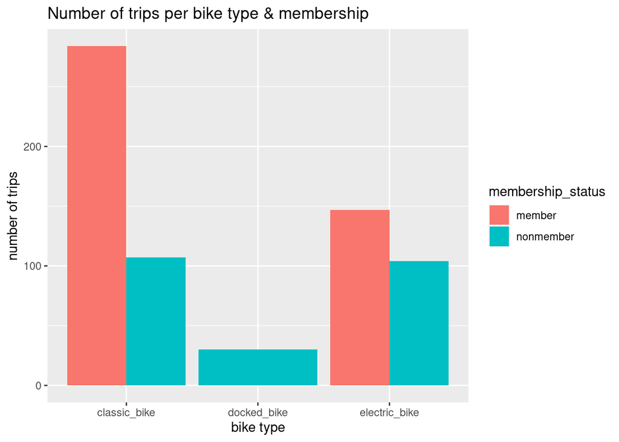

```r
ggplot(df_sampled, aes(x = bike_type, fill = membership_status)) +
  geom_bar(position = 'dodge') +
  labs(title = 'Number of trips per bike type & membership', x = 'bike type', y = 'number of trips')
```

We can see that the classic bike is the overall most popular option. However, nonmember riders are nearly tied for preferring the classic and electric bikes. Interestingly the docked bike is unpopular, with no member riders.

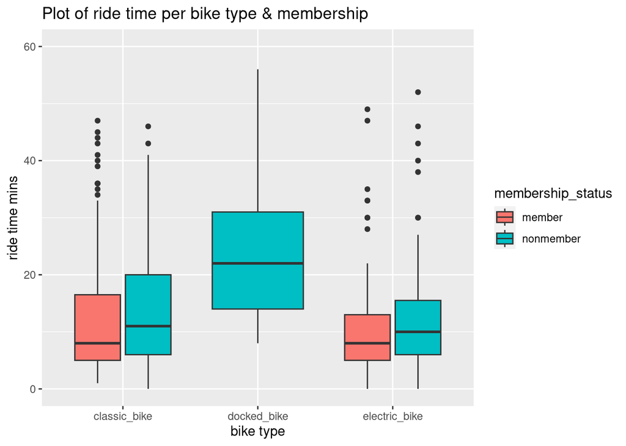

```r
ggplot(df_sampled, aes(x = bike_type, y = ride_time, fill = membership_status)) +
  geom_boxplot() +
  scale_y_continuous(limits = c(0, 60)) +
  labs(title = 'Plot of ride time per bike type & membership', x= 'bike type', y= 'ride time mins')
```

## Conclusion

The trend for nonmember riders is to ride less often but for longer than member riders. The current pricing scheme favors this preference. If it were changed to accommodate for fewer rides (per monthly for example) some nonmember riders may subscribe to member status.